# NHS Waiting List and Service Performance Analysis

Asif Khandokar

# 0. Project Overview

## 0.1 Project Aim

This project analyses NHS England referral-to-treatment (RTT) waiting-list data for three London NHS trusts between April 2024 and March 2026.

The aim is to examine changes in waiting-list size and waiting times, compare selected specialties, and identify patterns that warrant further investigation.

## 0.2 Research Questions

1. How have waiting-list sizes changed over the study period?
2. How have the percentages of pathways within 18 weeks and over 52 weeks changed?
3. Which selected specialties show increasing waiting lists or persistent long waits?
4. What differences between trusts warrant further investigation?

## 0.3 Project Scope

The selected trusts are:

- Barts Health NHS Trust (R1H).
- Imperial College Healthcare NHS Trust (RYJ).
- Guy’s and St Thomas’ NHS Foundation Trust (RJ1).

The selected specialties are:

- General Surgery Service (C_100).
- Trauma and Orthopaedic Service (C_110).
- Ophthalmology Service (C_130).

The data describe incomplete RTT pathways at the end of each reporting month. Pathways are not necessarily unique patients, because one patient can have more than one pathway.

# 1. Background and NHS Context

## 1.1 What Is Referral to Treatment?

Referral to Treatment (RTT) measures the time from referral to the start of consultant-led treatment for non-emergency care.

An incomplete RTT pathway represents a case where treatment has not yet started at the end of the reporting month. The patient may be waiting for a diagnostic test, a specialist appointment or a procedure.

A patient can have more than one pathway for different conditions. Therefore, pathway counts should not be interpreted as counts of unique patients.

## 1.2 Why Analyse Waiting Lists?

Waiting-list analysis helps service managers understand changes in the number of pathways awaiting treatment and the length of time people have been waiting.

Examining trends by trust and specialty can identify areas that need further investigation. However, waiting-list data alone cannot establish why performance has changed.

## 1.3 Measures Used in This Project

This project will examine:

- Total incomplete pathways: the waiting-list size at month-end.
- Percentage within 18 weeks: the proportion of incomplete pathways with a wait of no more than 18 weeks.
- Pathways waiting over 52 weeks: the number and proportion experiencing long waits.
- Median waiting time: the middle waiting time among incomplete pathways, as published in the dataset.
- Monthly and annual changes: movements in waiting-list size and waiting-time indicators.

## 1.4 Interpreting Comparisons

Trusts differ in size, services and the complexity of the patients they treat. A larger waiting list does not, by itself, indicate poorer performance.

This project compares the same selected specialties across trusts and examines both counts and percentages. Differences will be described as patterns requiring investigation rather than evidence of their underlying causes.

Monthly waiting lists are snapshots. Adding their totals across months would not give the number of distinct patients or pathways seen during the study period.

## 1.5 Source

NHS England: [Referral to Treatment Waiting Times — Data Collection](https://digital.nhs.uk/data-and-information/data-collections-and-data-sets/data-collections/consultant-led-referral-to-treatment-waiting-times-rtt).

# 2. Data Source and Definitions

## 2.1 Data Source

The data come from NHS England’s monthly Consultant-led Referral to Treatment (RTT) Waiting Times publications.

This project uses the “Provider” sheet from 24 monthly “Incomplete Provider” Excel workbooks covering April 2024 to March 2026.

The source publication pages are:

- [RTT Data 2024–25](https://www.england.nhs.uk/statistics/statistical-work-areas/rtt-waiting-times/rtt-data-2024-25/)
- [RTT Data 2025–26](https://www.england.nhs.uk/statistics/statistical-work-areas/rtt-waiting-times/rtt-data-2025-26/)

Original workbooks are retained unchanged in the data folder. Their filenames identify the reporting month and, where indicated, whether the file is revised.

## 2.2 Selected Trusts and Specialties

The analysis focuses on three London NHS trusts:

| Provider code | NHS trust |
| --- | --- |
| R1H | Barts Health NHS Trust |
| RYJ | Imperial College Healthcare NHS Trust |
| RJ1 | Guy’s and St Thomas’ NHS Foundation Trust |

Three specialties are selected:

| Treatment function code | Specialty |
| --- | --- |
| C_100 | General Surgery Service |
| C_110 | Trauma and Orthopaedic Service |
| C_130 | Ophthalmology Service |

These specialties are recorded for all three trusts throughout the selected period. Reporting coverage and missing values will also be checked within the R workflow.

## 2.3 Unit of Analysis

Each observation in the prepared specialty dataset will represent one trust, one specialty and one reporting month.

The expected dataset contains:

24 months × 3 trusts × 3 specialties = 216 observations.

These are aggregated observations, rather than individual patient records.

## 2.4 Variable Dictionary

| Prepared variable | Meaning | Type |
| --- | --- | --- |
| reporting_month | Reporting month, stored as its first day; measures describe month-end | Date |
| provider_code | Identifier for the NHS trust | Character |
| provider_name | Name of the NHS trust | Character |
| specialty_code | Published treatment function code | Character |
| specialty_name | Published treatment function name | Character |
| total_pathways | Total incomplete pathways at month-end | Numeric count |
| within_18_weeks | Number of incomplete pathways within 18 weeks | Numeric count |
| pct_within_18_weeks | Published proportion of incomplete pathways within 18 weeks | Numeric proportion (0–1) |
| over_52_weeks | Published “Total 52 plus weeks” count | Numeric count |
| pct_over_52_weeks | Proportion calculated as over_52_weeks / total_pathways | Numeric proportion (0–1) |
| median_wait_weeks | Published median waiting time in weeks, converted to numeric during cleaning | Numeric |
| source_file | Original workbook filename | Character |

These shorter names are assigned during data preparation. Proportions are multiplied by 100 when displayed as percentages in tables and charts.

## 2.5 Percentage Representation

Excel stores the percentage measures as proportions.

For example, a stored value of 0.65 represents 65%.

We will retain proportions for calculations and format them as percentages in tables and charts. A change from 60% to 65% is an increase of 5 percentage points.

## 2.6 Workbook Structure

In the March 2026 Provider sheet, the column headings appear on row 14 and the data begin on row 15.

The workbooks contain weekly waiting-time bands alongside published summary measures. Column headings vary slightly across the collected files, so the import process will check and standardise them.

Each trust also has a “Total” row with treatment function code C_999. These rows will be kept separate from specialty records to prevent double-counting.

The sum of our three selected specialties will be labelled as a selected-specialty total, rather than the whole trust’s waiting list.

## 2.7 Initial Data Quality Checks

Before analysis, the workflow will check:

- All 24 reporting months are present.
- Each trust–specialty–month combination is unique.
- Required measures are numeric and available.
- Pathway counts are non-negative whole numbers.
- Counts within 18 weeks and over 52 weeks do not exceed total pathways.
- Published proportions agree with their corresponding counts and totals, allowing for numerical precision.
- Missing values remain distinguishable from zero.

The presence of a record does not guarantee that it is complete or accurate. Any issues will be investigated and documented before interpreting the results.

# 3. R Setup and Data Import

## 3.1 Load Packages

Packages provide functions for importing Excel files, preparing data and creating visualisations.

```r
library(readxl)
library(dplyr)
```

```r
library(tidyr)
library(ggplot2)
```

## 3.2 Locate the Monthly Workbooks

The original Excel workbooks are stored in the project’s data folder. We search for Incomplete Provider files, including any stored in subfolders.

```r
# Find the monthly Provider workbooks.
rtt_files <- list.files(
  path = "data",
  pattern = "^Incomplete-Provider-.*\\.xlsx$",
  full.names = TRUE,
  recursive = TRUE,
  ignore.case = TRUE
)

# Check the number of files found.
length(rtt_files)
```

```
## [1] 24
```

```r
# Display their filenames.
basename(rtt_files)
```

```
##  [1] "Incomplete-Provider-Apr24-XLSX-8M-revised.xlsx"
##  [2] "Incomplete-Provider-Apr25-XLSX-9M-revised.xlsx"
##  [3] "Incomplete-Provider-Aug24-XLSX-9M-revised.xlsx"
##  [4] "Incomplete-Provider-Aug25-XLSX-9M-revised-2.xlsx"
##  [5] "Incomplete-Provider-Dec24-XLSX-9M-revised.xlsx"
##  [6] "Incomplete-Provider-Dec25-XLSX-9M-6jPlxd.xlsx"
##  [7] "Incomplete-Provider-Feb25-XLSX-9M-revised.xlsx"
##  [8] "Incomplete-Provider-Feb26-XLSX-9M-9j03fJT.xlsx"
##  [9] "Incomplete-Provider-Jan25-XLSX-9M-revised.xlsx"
## [10] "Incomplete-Provider-Jan26-XLSX-9M-WL5BiP.xlsx"
## [11] "Incomplete-Provider-Jul24-XLSX-8M-revised.xlsx"
## [12] "Incomplete-Provider-Jul25-XLSX-9M-revised-2.xlsx"
## [13] "Incomplete-Provider-Jun24-XLSX-8M-revised.xlsx"
## [14] "Incomplete-Provider-Jun25-XLSX-9M-revised.xlsx"
## [15] "Incomplete-Provider-Mar25-XLSX-9M-revised.xlsx"
## [16] "Incomplete-Provider-Mar26-XLSX-9M-revised.xlsx"
## [17] "Incomplete-Provider-May24-XLSX-8M-revised.xlsx"
## [18] "Incomplete-Provider-May25-XLSX-9M-revised.xlsx"
## [19] "Incomplete-Provider-Nov24-XLSX-9M-revised.xlsx"
## [20] "Incomplete-Provider-Nov25-XLSX-9M-1Xmjkk.xlsx"
## [21] "Incomplete-Provider-Oct24-XLSX-9M-revised.xlsx"
## [22] "Incomplete-Provider-Oct25-XLSX-9M-SrRW6y.xlsx"
## [23] "Incomplete-Provider-Sep24-XLSX-9M-revised.xlsx"
## [24] "Incomplete-Provider-Sep25-XLSX-9M-revised.xlsx"
```

The expected number of workbooks is 24. Finding 24 files is an initial check; we will verify their reporting months after importing them.

## 3.3 Import One Workbook

We first import a single workbook to understand its structure before combining all 24 months.

```r
# Locate the March 2026 workbook.
sample_file <- rtt_files[
  grepl("Incomplete-Provider-Mar26-", basename(rtt_files))
]

# Confirm exactly one matching file.
stopifnot(length(sample_file) == 1)

# Display the workbook's sheet names.
excel_sheets(sample_file)
```

```
## [1] "Provider"             "Provider with DTA"    "IS Provider"
## [4] "IS Provider with DTA" "Notes"                "Guidance"
```

```r
# Import the Provider sheet.
# Skip the first 13 rows so row 14 becomes the column headings.
rtt_sample <- read_excel(
  path = sample_file,
  sheet = "Provider",
  skip = 13
)
```

## 3.4 Inspect the Imported Data

We examine the dimensions, column names and first few records to check whether the import has worked as expected.

```r
# Number of rows and columns.
dim(rtt_sample)
```

```
## [1] 3600  119
```

```r
# Original column names.
names(rtt_sample)
```

```
##   [1] "Region Code"
##   [2] "Provider Code"
##   [3] "Provider Name"
##   [4] "Treatment Function Code"
##   [5] "Treatment Function"
##   [6] ">0-1"
##   [7] ">1-2"
##   [8] ">2-3"
##   [9] ">3-4"
##  [10] ">4-5"
##  [11] ">5-6"
##  [12] ">6-7"
##  [13] ">7-8"
##  [14] ">8-9"
##  [15] ">9-10"
```

[output cut: 104 more lines]

```r
# Display the first six records using the identifier columns.
head(
  rtt_sample %>%
    select(
      `Provider Code`,
      `Provider Name`,
      `Treatment Function Code`,
      `Treatment Function`
    )
)
```

```
## # A tibble: 6 × 4
##   `Provider Code` `Provider Name`    Treatment Function C…¹ `Treatment Function`
##   <chr>           <chr>              <chr>                  <chr>
## 1 R1H             BARTS HEALTH NHS … C_100                  General Surgery Ser…
## 2 R1H             BARTS HEALTH NHS … C_101                  Urology Service
## 3 R1H             BARTS HEALTH NHS … C_110                  Trauma and Orthopae…
## 4 R1H             BARTS HEALTH NHS … C_120                  Ear Nose and Throat…
## 5 R1H             BARTS HEALTH NHS … C_130                  Ophthalmology Servi…
## 6 R1H             BARTS HEALTH NHS … C_140                  Oral Surgery Service
## # ℹ abbreviated name: ¹`Treatment Function Code`
```

## 3.5 Select the Project Sample

We use provider and specialty codes to select the records relevant to the project. Codes provide more consistent identifiers than organisation names.

```r
# Define the three trusts.
selected_trusts <- c("R1H", "RYJ", "RJ1")

# Define the three specialties.
selected_specialties <- c("C_100", "C_110", "C_130")

# Select the relevant records and give columns shorter names.
rtt_sample_selected <- rtt_sample %>%
  filter(
    `Provider Code` %in% selected_trusts,
    `Treatment Function Code` %in% selected_specialties
  ) %>%
  transmute(
    provider_code = `Provider Code`,
    provider_name = `Provider Name`,
    specialty_code = `Treatment Function Code`,
    specialty_name = `Treatment Function`,
    total_pathways = `Total number of incomplete pathways`,
    within_18_weeks = `Total within 18 weeks`,
    pct_within_18_weeks = `% within 18 weeks`,
    over_52_weeks = `Total 52 plus weeks`,
    pct_over_52_weeks = `% 52 plus weeks`,
    median_wait_weeks = `Average (median) waiting time (in weeks)`
  )

# Check the number of selected records.
nrow(rtt_sample_selected)
```

```
## [1] 9
```

```r
# Display a compact table.
knitr::kable(
  rtt_sample_selected %>%
    select(
      provider_code,
      specialty_name,
      total_pathways,
      within_18_weeks,
      over_52_weeks
    ),
  caption = "Selected trust and specialty records: March 2026"
)
```

Selected trust and specialty records: March 2026

| provider_code | specialty_name | total_pathways | within_18_weeks | over_52_weeks |
| --- | --- | --- | --- | --- |
| R1H | General Surgery Service | 4918 | 2804 | 67 |
| R1H | Trauma and Orthopaedic Service | 8564 | 4773 | 72 |
| R1H | Ophthalmology Service | 5583 | 3782 | 3 |
| RJ1 | General Surgery Service | 1486 | 867 | 8 |
| RJ1 | Trauma and Orthopaedic Service | 4892 | 3182 | 80 |
| RJ1 | Ophthalmology Service | 3627 | 2865 | 1 |
| RYJ | General Surgery Service | 2064 | 1141 | 2 |
| RYJ | Trauma and Orthopaedic Service | 2881 | 1855 | 2 |
| RYJ | Ophthalmology Service | 5149 | 3929 | 9 |

## 3.6 Create a Monthly Import Function

A function lets us apply the same preparation steps to every workbook without copying the code 24 times.

We read the reporting period from cell C5, rather than relying only on the filename. Dates are stored as the first day of the reporting month for sorting and plotting; the measures describe the month-end waiting list.

```r
read_rtt_month <- function(file_path) {

  # Read the reporting period from the workbook.
  period_text <- read_excel(
    file_path,
    sheet = "Provider",
    range = "C5",
    col_names = FALSE
  )[[1]][1]

  # Convert the month name and year into a Date.
  period_parts <- strsplit(trimws(period_text), "\\s+")[[1]]
  month_number <- match(period_parts[1], month.name)
  year_number <- as.integer(period_parts[2])

  if (is.na(month_number) || is.na(year_number)) {
    stop("Could not identify reporting month: ", basename(file_path))
  }

  reporting_month <- as.Date(
    sprintf("%04d-%02d-01", year_number, month_number)
  )

  # Read the monthly Provider data.
  monthly_data <- read_excel(
    file_path,
    sheet = "Provider",
    skip = 13
  )

  # Select the project records and standardise column names.
  selected_data <- monthly_data %>%
    filter(
      `Provider Code` %in% selected_trusts,
      `Treatment Function Code` %in% selected_specialties
    ) %>%
    transmute(
      reporting_month = reporting_month,
      provider_code = `Provider Code`,
      provider_name = `Provider Name`,
      specialty_code = `Treatment Function Code`,
      specialty_name = `Treatment Function`,
      total_pathways = `Total number of incomplete pathways`,
      within_18_weeks = `Total within 18 weeks`,
      pct_within_18_weeks = `% within 18 weeks`,
      over_52_weeks = `Total 52 plus weeks`,
      median_wait_weeks = `Average (median) waiting time (in weeks)`,
      source_file = basename(file_path)
    ) %>%
    mutate(
      pct_over_52_weeks = over_52_weeks /
        na_if(total_pathways, 0)
    )

  return(selected_data)
}
```

## 3.7 Combine All Monthly Files

The lapply() function runs our import function once for each workbook. bind_rows() combines the resulting tables.

```r
# Import each workbook into a list of monthly tables.
rtt_monthly_list <- lapply(rtt_files, read_rtt_month)
# Combine and sort the records.
rtt_data <- bind_rows(rtt_monthly_list) %>%
  arrange(reporting_month, provider_code, specialty_code)

# Check the combined dataset.
nrow(rtt_data)
```

```
## [1] 216
```

```r
n_distinct(rtt_data$reporting_month)
```

```
## [1] 24
```

```r
range(rtt_data$reporting_month)
```

```
## [1] "2024-04-01" "2026-03-01"
```

```r
# Check the number of records in each month.
knitr::kable(
  rtt_data %>% count(reporting_month, name = "records"),
  caption = "Number of selected records per reporting month"
)
```

Number of selected records per reporting month

| reporting_month | records |
| --- | --- |
| 2024-04-01 | 9 |
| 2024-05-01 | 9 |
| 2024-06-01 | 9 |
| 2024-07-01 | 9 |
| 2024-08-01 | 9 |
| 2024-09-01 | 9 |
| 2024-10-01 | 9 |
| 2024-11-01 | 9 |
| 2024-12-01 | 9 |
| 2025-01-01 | 9 |
| 2025-02-01 | 9 |
| 2025-03-01 | 9 |
| 2025-04-01 | 9 |
| 2025-05-01 | 9 |
| 2025-06-01 | 9 |
| 2025-07-01 | 9 |
| 2025-08-01 | 9 |
| 2025-09-01 | 9 |
| 2025-10-01 | 9 |
| 2025-11-01 | 9 |
| 2025-12-01 | 9 |
| 2026-01-01 | 9 |
| 2026-02-01 | 9 |
| 2026-03-01 | 9 |

# 4. Initial Data Inspection

## 4.1 Inspect Dimensions and Variable Types

We check the size and structure of the combined dataset. Dates, identifiers and numerical measures should have appropriate types before analysis.

```r
# Number of rows and columns.
dim(rtt_data)
```

```
## [1] 216  12
```

```r
# Display each variable's type and sample values.
glimpse(rtt_data)
```

```
## Rows: 216
## Columns: 12
## $ reporting_month     <date> 2024-04-01, 2024-04-01, 2024-04-01, 2024-04-01, 2…
## $ provider_code       <chr> "R1H", "R1H", "R1H", "RJ1", "RJ1", "RJ1", "RYJ", "…
## $ provider_name       <chr> "BARTS HEALTH NHS TRUST", "BARTS HEALTH NHS TRUST"…
## $ specialty_code      <chr> "C_100", "C_110", "C_130", "C_100", "C_110", "C_13…
## $ specialty_name      <chr> "General Surgery Service", "Trauma and Orthopaedic…
## $ total_pathways      <dbl> 3035, 7707, 4968, 1186, 5287, 4177, 3201, 3415, 69…
## $ within_18_weeks     <dbl> 1562, 4073, 3043, 573, 2684, 2653, 1220, 1714, 404…
## $ pct_within_18_weeks <dbl> 0.5146623, 0.5284806, 0.6125201, 0.4831366, 0.5076…
## $ over_52_weeks       <dbl> 244, 439, 37, 34, 418, 28, 511, 137, 70, 239, 406,…
## $ median_wait_weeks   <chr> "16.9153846153846", "15.9790419161677", "12.732026…
## $ source_file         <chr> "Incomplete-Provider-Apr24-XLSX-8M-revised.xlsx", …
## $ pct_over_52_weeks   <dbl> 0.080395387, 0.056961204, 0.007447665, 0.028667791…
```

## 4.2 Summarise Numerical Measures

Summary statistics provide an initial view of the ranges and distributions. They can also reveal missing values or unexpected measurements.

```r
rtt_data %>%
  select(
    total_pathways,
    within_18_weeks,
    pct_within_18_weeks,
    over_52_weeks,
    pct_over_52_weeks,
    median_wait_weeks
  ) %>%
  summary()
```

```
##  total_pathways within_18_weeks pct_within_18_weeks over_52_weeks
##  Min.   : 709   Min.   : 438    Min.   :0.3811      Min.   :  0.0
##  1st Qu.:2953   1st Qu.:1558    1st Qu.:0.5226      1st Qu.: 18.0
##  Median :4362   Median :2798    Median :0.5781      Median : 64.0
##  Mean   :4377   Mean   :2624    Mean   :0.5960      Mean   :110.7
##  3rd Qu.:5408   3rd Qu.:3606    3rd Qu.:0.6697      3rd Qu.:182.2
##  Max.   :9628   Max.   :5482    Max.   :0.7899      Max.   :517.0
##  pct_over_52_weeks  median_wait_weeks
##  Min.   :0.000000   Length   :216
##  1st Qu.:0.005701   N.unique :216
##  Median :0.017166   N.blank  :  0
##  Mean   :0.026555   Min.nchar:  2
##  3rd Qu.:0.040083   Max.nchar: 18
##  Max.   :0.163971
```

## 4.3 Check Coverage by Trust and Specialty

Each trust–specialty combination should have 24 records, one for each reporting month. Duplicate and missing-month checks will follow in Section 5.

```r
knitr::kable(
  rtt_data %>%
    count(provider_code, specialty_code, specialty_name,
          name = "records"),
  caption = "Record counts by trust and specialty"
)
```

Record counts by trust and specialty

| provider_code | specialty_code | specialty_name | records |
| --- | --- | --- | --- |
| R1H | C_100 | General Surgery Service | 24 |
| R1H | C_110 | Trauma and Orthopaedic Service | 24 |
| R1H | C_130 | Ophthalmology Service | 24 |
| RJ1 | C_100 | General Surgery Service | 24 |
| RJ1 | C_110 | Trauma and Orthopaedic Service | 24 |
| RJ1 | C_130 | Ophthalmology Service | 24 |
| RYJ | C_100 | General Surgery Service | 24 |
| RYJ | C_110 | Trauma and Orthopaedic Service | 24 |
| RYJ | C_130 | Ophthalmology Service | 24 |

# 5. Data Cleaning and Quality Assurance

## 5.1 Correct the Median Waiting-Time Type

The median waiting-time column was imported as text. We convert it to numeric and check whether any non-missing values fail conversion.

```r
# Retain the original values for checking.
median_wait_original <- rtt_data$median_wait_weeks

# Convert text values to numbers.
median_wait_numeric <- as.numeric(
  trimws(as.character(median_wait_original))
)

# Identify values that could not be converted.
conversion_issues <- rtt_data %>%
  filter(
    !is.na(median_wait_original),
    is.na(median_wait_numeric)
  ) %>%
  select(
    reporting_month,
    provider_code,
    specialty_code,
    median_wait_weeks,
    source_file
  )

# Display any conversion issues.
nrow(conversion_issues)
```

```
## [1] 0
```

```r
conversion_issues
```

```
## # A tibble: 0 × 5
## # ℹ 5 variables: reporting_month <date>, provider_code <chr>,
## #   specialty_code <chr>, median_wait_weeks <chr>, source_file <chr>
```

```r
# Stop if conversion would lose an existing value.
stopifnot(nrow(conversion_issues) == 0)

# Apply the checked conversion.
rtt_data$median_wait_weeks <- median_wait_numeric

# Confirm the corrected type and numerical summary.
class(rtt_data$median_wait_weeks)
```

```
## [1] "numeric"
```

```r
summary(rtt_data$median_wait_weeks)
```

```
##    Min. 1st Qu.  Median    Mean 3rd Qu.    Max.
##    8.28   11.94   14.61   14.55   16.92   25.49
```

## 5.2 Check Duplicate Records

Each trust–specialty–month combination should appear once. We flag repeated combinations for investigation rather than deleting them automatically.

```r
duplicate_records <- rtt_data %>%
  count(reporting_month, provider_code, specialty_code) %>%
  filter(n > 1)
```

## 5.3 Check Missing Combinations

We compare the observed records with all expected combinations of 24 months, three trusts and three specialties.

```r
expected_records <- expand_grid(
  reporting_month = seq(
    as.Date("2024-04-01"),
    as.Date("2026-03-01"),
    by = "month"
  ),
  provider_code = selected_trusts,
  specialty_code = selected_specialties
)

missing_records <- expected_records %>%
  anti_join(
    rtt_data,
    by = c("reporting_month", "provider_code", "specialty_code")
  )

unexpected_records <- rtt_data %>%
  anti_join(
    expected_records,
    by = c("reporting_month", "provider_code", "specialty_code")
  )
```

## 5.4 Check Missing Values

Missing values are counted for every variable. They are not replaced with zero because missing and zero have different meanings.

```r
missing_values <- data.frame(
  variable = names(rtt_data),
  missing_count = as.integer(colSums(is.na(rtt_data)))
)

knitr::kable(
  missing_values,
  caption = "Missing values by variable"
)
```

Missing values by variable

| variable | missing_count |
| --- | --- |
| reporting_month | 0 |
| provider_code | 0 |
| provider_name | 0 |
| specialty_code | 0 |
| specialty_name | 0 |
| total_pathways | 0 |
| within_18_weeks | 0 |
| pct_within_18_weeks | 0 |
| over_52_weeks | 0 |
| median_wait_weeks | 0 |
| source_file | 0 |
| pct_over_52_weeks | 0 |

## 5.5 Summarise Record Coverage Checks

```r
coverage_checks <- data.frame(
  check = c(
    "Duplicate trust–specialty–month combinations",
    "Missing expected combinations",
    "Records outside the project scope"
  ),
  issues_found = c(
    nrow(duplicate_records),
    nrow(missing_records),
    nrow(unexpected_records)
  )
)

knitr::kable(
  coverage_checks,
  caption = "Record coverage checks"
)
```

Record coverage checks

| check | issues_found |
| --- | --- |
| Duplicate trust–specialty–month combinations | 0 |
| Missing expected combinations | 0 |
| Records outside the project scope | 0 |

## 5.6 Validate Numerical Measures

Counts should be non-negative whole numbers. Waiting-time proportions should lie between zero and one, and subgroup counts should not exceed total pathways.

We also compare the published proportion within 18 weeks with the proportion calculated from its count and total.

```r
# Small tolerance for numerical precision.
tolerance <- 1e-8

# Identify records with invalid numerical measures.
invalid_records <- rtt_data %>%
  filter(
    !is.finite(total_pathways) |
    !is.finite(within_18_weeks) |
    !is.finite(over_52_weeks) |
    !is.finite(pct_within_18_weeks) |
    !is.finite(pct_over_52_weeks) |
    !is.finite(median_wait_weeks) |
    total_pathways < 0 |
    within_18_weeks < 0 |
    over_52_weeks < 0 |
    total_pathways != floor(total_pathways) |
    within_18_weeks != floor(within_18_weeks) |
    over_52_weeks != floor(over_52_weeks) |
    within_18_weeks > total_pathways |
    over_52_weeks > total_pathways |
    within_18_weeks + over_52_weeks > total_pathways |
    pct_within_18_weeks < 0 |
    pct_within_18_weeks > 1 |
    pct_over_52_weeks < 0 |
    pct_over_52_weeks > 1 |
    median_wait_weeks < 0
  )

# Compare the published proportion with an independent calculation.
percentage_mismatches <- rtt_data %>%
  mutate(
    calculated_proportion = within_18_weeks /
      na_if(total_pathways, 0),
    difference = abs(
      pct_within_18_weeks - calculated_proportion
    )
  ) %>%
  filter(
    is.na(calculated_proportion) |
    difference > tolerance
  )

# Display the validation results.
numerical_checks <- data.frame(
  check = c(
    "Records with invalid numerical measures",
    "Published 18-week proportion mismatches"
  ),
  issues_found = c(
    nrow(invalid_records),
    nrow(percentage_mismatches)
  )
)

knitr::kable(
  numerical_checks,
  caption = "Numerical validation checks"
)
```

Numerical validation checks

| check | issues_found |
| --- | --- |
| Records with invalid numerical measures | 0 |
| Published 18-week proportion mismatches | 0 |

```r
stopifnot(
  nrow(duplicate_records) == 0,
  nrow(missing_records) == 0,
  nrow(unexpected_records) == 0,
  all(missing_values$missing_count == 0),
  nrow(invalid_records) == 0,
  nrow(percentage_mismatches) == 0
)
```

# 6. Calculating Performance Indicators

## 6.1 Calculate Monthly and Annual Changes

Changes are calculated separately for each trust and specialty, with records ordered by reporting month.

Waiting-list changes are expressed as counts and percentages. Changes in waiting-time proportions are expressed in percentage points.

```r
rtt_analysis <- rtt_data %>%
  group_by(provider_code, specialty_code) %>%
  arrange(reporting_month, .by_group = TRUE) %>%
  mutate(
    # Change from the preceding month.
    monthly_change_pathways =
      total_pathways - lag(total_pathways),

    monthly_change_pct =
      100 * monthly_change_pathways /
      na_if(lag(total_pathways), 0),

    monthly_change_18wk_pp =
      100 * (
        pct_within_18_weeks -
        lag(pct_within_18_weeks)
      ),

    # Change from the same month one year earlier.
    annual_change_pathways =
      total_pathways - lag(total_pathways, 12),

    annual_change_pct =
      100 * annual_change_pathways /
      na_if(lag(total_pathways, 12), 0),

    annual_change_18wk_pp =
      100 * (
        pct_within_18_weeks -
        lag(pct_within_18_weeks, 12)
      ),

    annual_change_52wk_pp =
      100 * (
        pct_over_52_weeks -
        lag(pct_over_52_weeks, 12)
      )
  ) %>%
  ungroup() %>%
  arrange(reporting_month, provider_code, specialty_code)
```

The first month of each series has no monthly comparison. The first 12 months have no annual comparison. These missing change values are expected because earlier observations are outside the study period.

Using a 12-row lag represents one year here because our coverage checks confirmed one record per consecutive month for each trust–specialty combination.

## 6.2 Inspect the Latest Annual Changes

The table compares March 2026 with March 2025.

```r
latest_changes <- rtt_analysis %>%
  filter(reporting_month == max(reporting_month)) %>%
  select(
    provider_code,
    specialty_name,
    total_pathways,
    annual_change_pathways,
    annual_change_pct,
    annual_change_18wk_pp,
    annual_change_52wk_pp
  )

knitr::kable(
  latest_changes,
  digits = 2,
  col.names = c(
    "Trust",
    "Specialty",
    "Pathways",
    "Annual change",
    "Annual change (%)",
    "Within 18 weeks change (pp)",
    "Over 52 weeks change (pp)"
  ),
  caption = "March 2026 compared with March 2025"
)
```

March 2026 compared with March 2025

| Trust | Specialty | Pathways | Annual change | Annual change (%) | Within 18 weeks change (pp) | Over 52 weeks change (pp) |
| --- | --- | --- | --- | --- | --- | --- |
| R1H | General Surgery Service | 4918 | 488 | 11.02 | 5.91 | -2.16 |
| R1H | Trauma and Orthopaedic Service | 8564 | 873 | 11.35 | 4.37 | -1.51 |
| R1H | Ophthalmology Service | 5583 | 1000 | 21.82 | -4.79 | -0.34 |
| RJ1 | General Surgery Service | 1486 | 704 | 90.03 | -16.34 | -1.38 |
| RJ1 | Trauma and Orthopaedic Service | 4892 | 608 | 14.19 | 4.14 | -0.37 |
| RJ1 | Ophthalmology Service | 3627 | -612 | -14.44 | 10.06 | -0.14 |
| RYJ | General Surgery Service | 2064 | -287 | -12.21 | 7.43 | -5.05 |
| RYJ | Trauma and Orthopaedic Service | 2881 | -239 | -7.66 | 10.19 | -2.46 |
| RYJ | Ophthalmology Service | 5149 | -590 | -10.28 | 6.21 | -0.31 |

# 7. Exploratory Analysis and Visualisation

## 7.1 How Have Waiting-List Sizes Changed?

We plot monthly incomplete pathways by trust, with a separate panel for each specialty. Counts represent month-end snapshots.

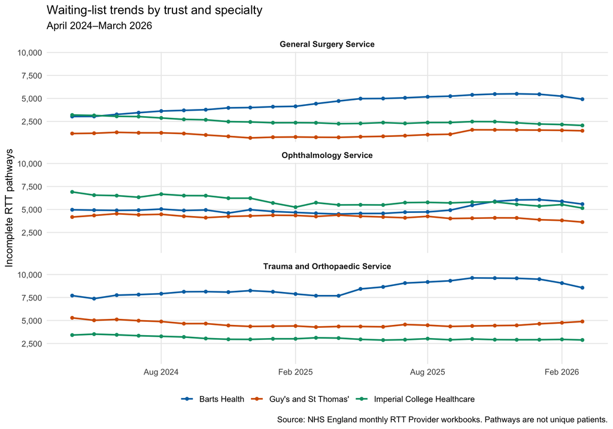

```r
# Create readable trust labels for charts.
trust_labels <- c(
  "R1H" = "Barts Health",
  "RJ1" = "Guy's and St Thomas'",
  "RYJ" = "Imperial College Healthcare"
)

ggplot(
  rtt_analysis,
  aes(
    x = reporting_month,
    y = total_pathways,
    colour = provider_code,
    group = provider_code
  )
) +
  geom_line(linewidth = 0.9) +
  geom_point(size = 1.4) +
  facet_wrap(
    ~ specialty_name,
    ncol = 1,
    labeller = label_wrap_gen(width = 40)
  ) +
  scale_colour_manual(
    values = c(
      "R1H" = "#0072B2",
      "RJ1" = "#D55E00",
      "RYJ" = "#009E73"
    ),
    breaks = names(trust_labels),
    labels = unname(trust_labels)
  ) +
  scale_x_date(
    date_breaks = "6 months",
    date_labels = "%b %Y"
  ) +
  scale_y_continuous(
    labels = function(x) {
      format(x, big.mark = ",", scientific = FALSE, trim = TRUE)
    }
  ) +
  labs(
    title = "Waiting-list trends by trust and specialty",
    subtitle = "April 2024–March 2026",
    x = NULL,
    y = "Incomplete RTT pathways",
    colour = NULL,
    caption = paste(
      "Source: NHS England monthly RTT Provider workbooks.",
      "Pathways are not unique patients."
    )
  ) +
  theme_minimal(base_size = 12) +
  theme(
    legend.position = "bottom",
    panel.grid.minor = element_blank(),
    strip.text = element_text(face = "bold")
  )
```

All panels use the same vertical scale to support comparison of waiting-list sizes. Differences in trust size and service mix should be considered when interpreting the counts.

### Interpretation

Barts Health recorded growth in General Surgery and Trauma and Orthopaedics waiting lists during much of 2025, followed by reductions towards March 2026. Imperial College Healthcare showed an overall decline across the three selected specialties.

At Guy’s and St Thomas’, the General Surgery waiting list declined during 2024 before increasing during 2025. Its large March 2025–March 2026 percentage increase should therefore be considered alongside the relatively low starting count.

These trends describe changes in month-end waiting-list sizes. They do not establish whether changes resulted from referral demand, treatment activity, administrative changes or other factors.

## 7.2 How Has the Proportion Within 18 Weeks Changed?

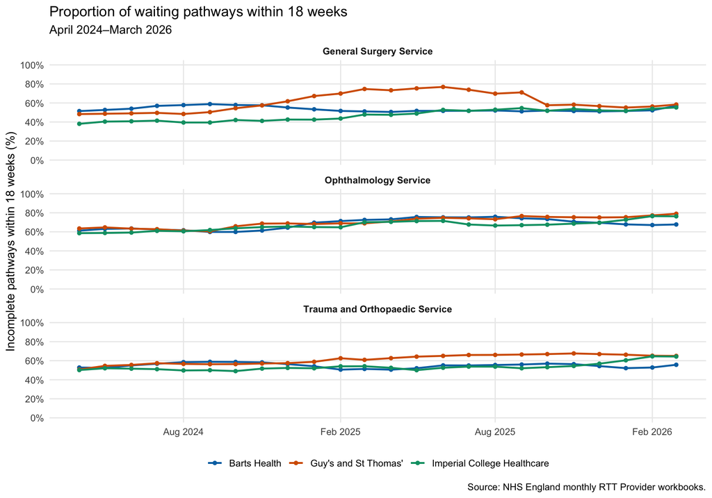

```r
ggplot(
  rtt_analysis,
  aes(
    x = reporting_month,
    y = pct_within_18_weeks,
    colour = provider_code,
    group = provider_code
  )
) +
  geom_line(linewidth = 0.9) +
  geom_point(size = 1.4) +
  facet_wrap(
    ~ specialty_name,
    ncol = 1,
    labeller = label_wrap_gen(width = 40)
  ) +
  scale_colour_manual(
    values = c(
      "R1H" = "#0072B2",
      "RJ1" = "#D55E00",
      "RYJ" = "#009E73"
    ),
    breaks = names(trust_labels),
    labels = unname(trust_labels)
  ) +
  scale_x_date(
    date_breaks = "6 months",
    date_labels = "%b %Y"
  ) +
  scale_y_continuous(
    limits = c(0, 1),
    breaks = seq(0, 1, 0.2),
    labels = function(x) paste0(round(x * 100), "%")
  ) +
  labs(
    title = "Proportion of waiting pathways within 18 weeks",
    subtitle = "April 2024–March 2026",
    x = NULL,
    y = "Incomplete pathways within 18 weeks (%)",
    colour = NULL,
    caption = "Source: NHS England monthly RTT Provider workbooks."
  ) +
  theme_minimal(base_size = 12) +
  theme(
    legend.position = "bottom",
    panel.grid.minor = element_blank(),
    strip.text = element_text(face = "bold")
  )
```

Higher values indicate a larger share of the month-end waiting list within 18 weeks. This is not the percentage of patients treated within 18 weeks during that month.

### Interpretation

General Surgery shows different patterns across the trusts. Imperial’s proportion within 18 weeks increased over the study period. Guy’s and St Thomas’ improved into early 2025, then declined, with a marked fall around October 2025. This change warrants investigation alongside its growing waiting list; the chart alone cannot establish the cause.

In Ophthalmology, Guy’s and St Thomas’ and Imperial ended the period with higher proportions within 18 weeks than at the start. Barts improved into 2025 before declining towards the end of the period.

In Trauma and Orthopaedics, Guy’s and St Thomas’ and Imperial generally improved over the full period. Barts fluctuated and finished below the other two trusts.

The count and proportion charts should be read together. Waiting-list growth can occur alongside an increase in the share within 18 weeks, as seen in Barts’ annual General Surgery and Orthopaedics comparisons.

## 7.3 How Has the Proportion Waiting Over 52 Weeks Changed?

We examine long waits as a share of each specialty’s month-end waiting list. A falling proportion does not necessarily mean the number of long-wait pathways fell, so counts will also be considered when interpreting results.

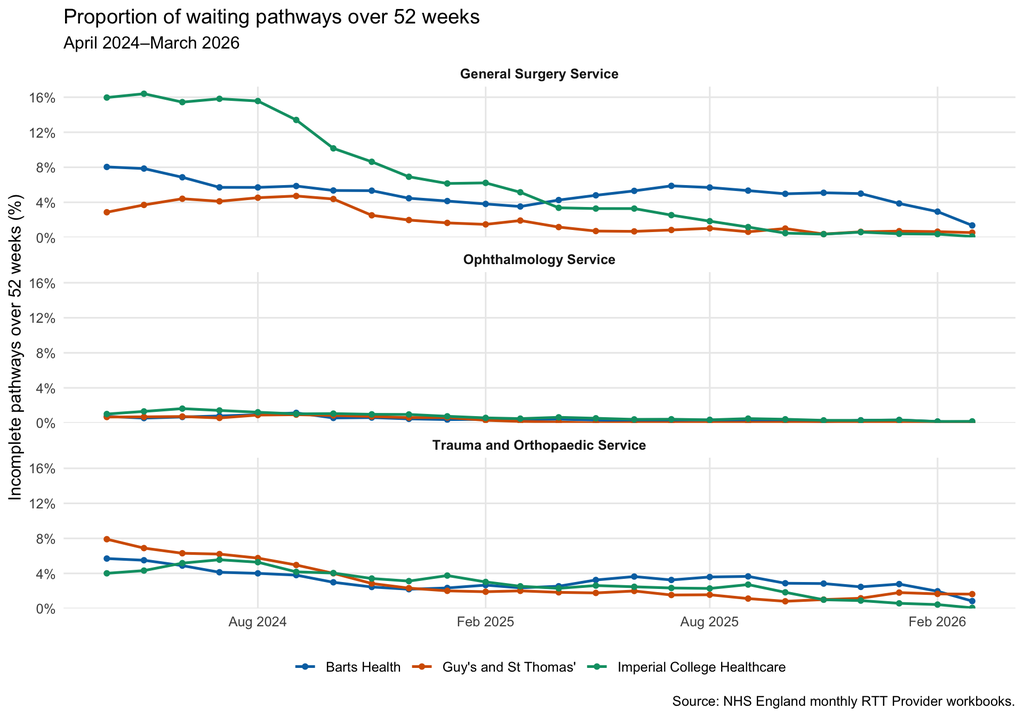

```r
ggplot(
  rtt_analysis,
  aes(
    x = reporting_month,
    y = pct_over_52_weeks,
    colour = provider_code,
    group = provider_code
  )
) +
  geom_line(linewidth = 0.9) +
  geom_point(size = 1.4) +
  facet_wrap(
    ~ specialty_name,
    ncol = 1,
    labeller = label_wrap_gen(width = 40)
  ) +
  scale_colour_manual(
    values = c(
      "R1H" = "#0072B2",
      "RJ1" = "#D55E00",
      "RYJ" = "#009E73"
    ),
    breaks = names(trust_labels),
    labels = unname(trust_labels)
  ) +
  scale_x_date(
    date_breaks = "6 months",
    date_labels = "%b %Y"
  ) +
  scale_y_continuous(
    labels = function(x) paste0(round(x * 100, 1), "%"),
    expand = expansion(mult = c(0, 0.05))
  ) +
  expand_limits(y = 0) +
  labs(
    title = "Proportion of waiting pathways over 52 weeks",
    subtitle = "April 2024–March 2026",
    x = NULL,
    y = "Incomplete pathways over 52 weeks (%)",
    colour = NULL,
    caption = "Source: NHS England monthly RTT Provider workbooks."
  ) +
  theme_minimal(base_size = 12) +
  theme(
    legend.position = "bottom",
    panel.grid.minor = element_blank(),
    strip.text = element_text(face = "bold")
  )
```

Lower values indicate a smaller share of pathways experiencing waits over 52 weeks. All panels use the same vertical scale.

### Interpretation

Imperial’s General Surgery long-wait proportion fell from approximately 16% in April 2024 to below 1% by March 2026. Barts also ended the period substantially lower, although its proportion increased during part of 2025 before falling.

In Trauma and Orthopaedics, all three trusts ended with lower long-wait proportions than at the start. Temporary increases show that the improvement was not continuous.

Ophthalmology long-wait proportions remained comparatively low and approached zero towards the end of the period. The shared vertical scale makes smaller differences in this specialty less visible.

These results describe proportions. Changes in the number of long-wait pathways must also be examined to distinguish a falling count from an increase in the total waiting list.

# 8. Trust and Specialty Comparisons

## 8.1 Compare the Latest Reporting Month

We compare trusts within each specialty using waiting-list counts, waiting-time proportions and median waiting times.

```r
latest_performance <- rtt_analysis %>%
  filter(reporting_month == max(reporting_month)) %>%
  arrange(specialty_code, provider_code) %>%
  transmute(
    Trust = unname(trust_labels[provider_code]),
    Specialty = specialty_name,
    Pathways = total_pathways,
    `Within 18 weeks (%)` = 100 * pct_within_18_weeks,
    `Over 52 weeks (count)` = over_52_weeks,
    `Over 52 weeks (%)` = 100 * pct_over_52_weeks,
    `Median wait (weeks)` = median_wait_weeks
  )

knitr::kable(
  latest_performance,
  digits = 2,
  caption = "Selected specialty performance: March 2026"
)
```

Selected specialty performance: March 2026

| Trust | Specialty | Pathways | Within 18 weeks (%) | Over 52 weeks (count) | Over 52 weeks (%) | Median wait (weeks) |
| --- | --- | --- | --- | --- | --- | --- |
| Barts Health | General Surgery Service | 4918 | 57.02 | 67 | 1.36 | 15.05 |
| Guy’s and St Thomas’ | General Surgery Service | 1486 | 58.34 | 8 | 0.54 | 15.18 |
| Imperial College Healthcare | General Surgery Service | 2064 | 55.28 | 2 | 0.10 | 15.51 |
| Barts Health | Trauma and Orthopaedic Service | 8564 | 55.73 | 72 | 0.84 | 15.83 |
| Guy’s and St Thomas’ | Trauma and Orthopaedic Service | 4892 | 65.04 | 80 | 1.64 | 11.47 |
| Imperial College Healthcare | Trauma and Orthopaedic Service | 2881 | 64.39 | 2 | 0.07 | 12.44 |
| Barts Health | Ophthalmology Service | 5583 | 67.74 | 3 | 0.05 | 11.64 |
| Guy’s and St Thomas’ | Ophthalmology Service | 3627 | 78.99 | 1 | 0.03 | 8.28 |
| Imperial College Healthcare | Ophthalmology Service | 5149 | 76.31 | 9 | 0.17 | 8.38 |

The comparisons are descriptive and are not adjusted for patient complexity or differences in service provision. They do not represent whole-trust performance.

### Interpretation

In March 2026, ophthalmology had the highest proportion of pathways within 18 weeks and the shortest median waiting time at each of the three selected trusts.

For trauma and orthopaedics, Barts Health had the largest waiting list (8,564 pathways), the lowest proportion within 18 weeks (55.73%) and the longest median wait (15.83 weeks). However, Guy’s and St Thomas’ had the highest number and proportion waiting over 52 weeks: 80 pathways, representing 1.64% of its specialty waiting list.

General surgery results were relatively close for the proportion within 18 weeks, ranging from 55.28% to 58.34%. The proportion waiting over 52 weeks varied more, from 0.10% at Imperial College Healthcare to 1.36% at Barts Health.

These measures describe different parts of the waiting-time distribution. A shorter median wait does not necessarily mean fewer very long waits. Comparisons are descriptive and do not account for differences in case complexity, referral patterns or service provision.

## 8.2 Changes in the Number of Long-Wait Pathways

The previous chart showed the proportion of pathways waiting over 52 weeks. This comparison examines the underlying counts between March 2025 and March 2026, alongside changes in those proportions.

```r
# Calculate annual changes within each trust and specialty.
long_wait_changes <- rtt_analysis %>%
  group_by(provider_code, specialty_code) %>%
  arrange(reporting_month, .by_group = TRUE) %>%
  mutate(
    previous_year_over_52 = lag(over_52_weeks, 12),
    annual_change_over_52 = over_52_weeks - previous_year_over_52
  ) %>%
  ungroup()

# Display the latest month and its comparison with one year earlier.
long_wait_comparison <- long_wait_changes %>%
  filter(reporting_month == max(reporting_month)) %>%
  arrange(specialty_code, provider_code) %>%
  transmute(
    Trust = unname(trust_labels[provider_code]),
    Specialty = specialty_name,
    `Over 52 weeks: March 2025` = previous_year_over_52,
    `Over 52 weeks: March 2026` = over_52_weeks,
    `Change in count` = annual_change_over_52,
    `Change in proportion (pp)` = annual_change_52wk_pp
  )

knitr::kable(
  long_wait_comparison,
  digits = 2,
  caption = "Pathways waiting over 52 weeks: March 2025 to March 2026"
)
```

Pathways waiting over 52 weeks: March 2025 to March 2026

| Trust | Specialty | Over 52 weeks: March 2025 | Over 52 weeks: March 2026 | Change in count | Change in proportion (pp) |
| --- | --- | --- | --- | --- | --- |
| Barts Health | General Surgery Service | 156 | 67 | -89 | -2.16 |
| Guy’s and St Thomas’ | General Surgery Service | 15 | 8 | -7 | -1.38 |
| Imperial College Healthcare | General Surgery Service | 121 | 2 | -119 | -5.05 |
| Barts Health | Trauma and Orthopaedic Service | 181 | 72 | -109 | -1.51 |
| Guy’s and St Thomas’ | Trauma and Orthopaedic Service | 86 | 80 | -6 | -0.37 |
| Imperial College Healthcare | Trauma and Orthopaedic Service | 79 | 2 | -77 | -2.46 |
| Barts Health | Ophthalmology Service | 18 | 3 | -15 | -0.34 |
| Guy’s and St Thomas’ | Ophthalmology Service | 7 | 1 | -6 | -0.14 |
| Imperial College Healthcare | Ophthalmology Service | 28 | 9 | -19 | -0.31 |

### Interpretation

Between March 2025 and March 2026, the number and proportion of pathways waiting over 52 weeks decreased in every selected trust–specialty combination.

Imperial College Healthcare recorded the largest absolute reduction in general surgery, from 121 to 2 pathways. Barts Health recorded the largest absolute reduction in trauma and orthopaedics, from 181 to 72 pathways.

Guy’s and St Thomas’ recorded a smaller reduction in orthopaedics, from 86 to 80 pathways. In March 2026, this remained the highest long-wait count and proportion among the three selected trusts for that specialty.

These are changes in month-end snapshots. They do not establish whether pathways left the waiting list through treatment, other removals or reporting changes.

## 8.3 Summary Heatmap of Annual Changes

These heatmaps summarise changes between March 2025 and March 2026 across the selected trusts and specialties. Labels show the exact change, rounded to two decimal places.

Each panel uses its own colour scale. Waiting-list changes are expressed as percentages; changes in waiting-time proportions are expressed in percentage points (pp).

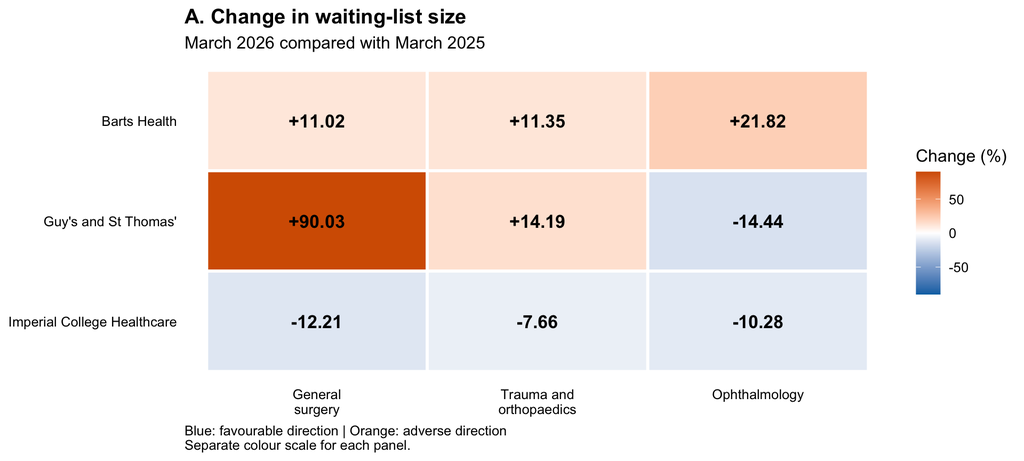

```r
# Select the latest reporting month.
heatmap_data <- rtt_analysis %>%
  filter(reporting_month == max(reporting_month)) %>%
  mutate(
    trust = factor(
      provider_code,
      levels = c("RYJ", "RJ1", "R1H"),
      labels = c(
        "Imperial College Healthcare",
        "Guy's and St Thomas'",
        "Barts Health"
      )
    ),
    specialty = factor(
      specialty_code,
      levels = c("C_100", "C_110", "C_130"),
      labels = c(
        "General\nsurgery",
        "Trauma and\northopaedics",
        "Ophthalmology"
      )
    )
  )

# Create one heatmap for a specified measure.
make_change_heatmap <- function(data, measure, title, unit,
                                higher_is_favourable = FALSE) {

  plot_data <- data %>%
    mutate(
      change = .data[[measure]],
      cell_label = sprintf("%+.2f", change)
    )

  # Centre the colour scale on zero with symmetric limits.
  colour_limit <- max(abs(plot_data$change), na.rm = TRUE)

  if (colour_limit == 0) {
    colour_limit <- 1
  }

  # For within-18-week performance, increases are favourable.
  # For waiting-list size and over-52-week share, decreases
  # are treated as the favourable direction.
  low_colour <- if (higher_is_favourable) "#D55E00" else "#0072B2"
  high_colour <- if (higher_is_favourable) "#0072B2" else "#D55E00"

  ggplot(plot_data, aes(x = specialty, y = trust, fill = change)) +
    geom_tile(colour = "white", linewidth = 1) +
    geom_text(
      aes(label = cell_label),
      colour = "black",
      size = 4.5,
      fontface = "bold"
    ) +
    scale_fill_gradient2(
      low = low_colour,
      mid = "white",
      high = high_colour,
      midpoint = 0,
      limits = c(-colour_limit, colour_limit),
      name = unit
    ) +
    labs(
      title = title,
      subtitle = "March 2026 compared with March 2025",
      x = NULL,
      y = NULL,
      caption = paste(
        "Blue: favourable direction | Orange: adverse direction",
        "Separate colour scale for each panel.",
        sep = "\n"
      )
    ) +
    theme_minimal(base_size = 12) +
    theme(
      panel.grid = element_blank(),
      axis.text = element_text(colour = "black"),
      plot.title = element_text(face = "bold"),
      plot.caption = element_text(hjust = 0),
      legend.position = "right"
    )
}

# Print each panel separately so labels remain readable.
print(make_change_heatmap(
  heatmap_data,
  measure = "annual_change_pct",
  title = "A. Change in waiting-list size",
  unit = "Change (%)"
))
```

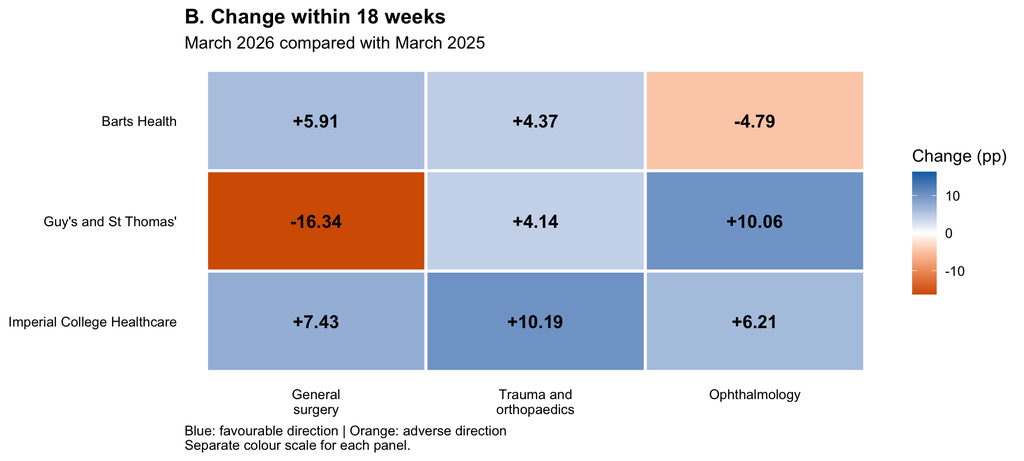

```r
print(make_change_heatmap(
  heatmap_data,
  measure = "annual_change_18wk_pp",
  title = "B. Change within 18 weeks",
  unit = "Change (pp)",
  higher_is_favourable = TRUE
))
```

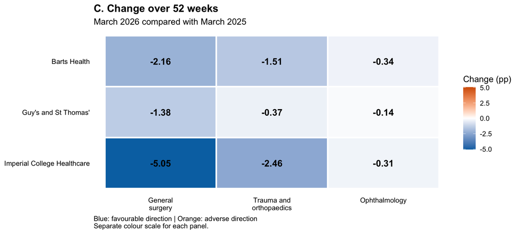

```r
print(make_change_heatmap(
  heatmap_data,
  measure = "annual_change_52wk_pp",
  title = "C. Change over 52 weeks",
  unit = "Change (pp)"
))
```

### Interpretation

The heatmaps show different patterns across the three indicators. Waiting-list size increased in five of the nine combinations, while the proportion within 18 weeks improved in seven. The proportion waiting over 52 weeks decreased in all nine.

General surgery at Guy’s and St Thomas’ and ophthalmology at Barts Health combined waiting-list growth with a declining proportion within 18 weeks. Imperial College Healthcare recorded smaller lists and improvements in both waiting-time proportions across all three selected specialties.

Colour intensity should be compared within each panel, rather than across panels, because the measures have separate scales. A smaller waiting list is treated here as a favourable direction, but its causes require investigation: reductions may reflect treatment, other removals or changes in referrals or reporting.

# 9. Key Findings and Recommendations

## 9.1 Key Findings

### Long waits reduced across all selected services

All nine trust–specialty combinations recorded fewer pathways waiting over 52 weeks in March 2026 than in March 2025. The proportion waiting over 52 weeks also fell in every combination. However, improvements in very long waits did not always coincide with improvements in the proportion within 18 weeks.

### General surgery at Guy’s and St Thomas’ warrants investigation

The general surgery waiting list increased from 782 to 1,486 pathways between March 2025 and March 2026, an increase of 90.03%. Over the same period, the proportion within 18 weeks fell by 16.34 percentage points.

The large percentage increase should be interpreted alongside the relatively small March 2025 baseline. Although pathways waiting over 52 weeks decreased from 15 to 8, the broader waiting-time measures indicate a need for further investigation.

### Barts Health ophthalmology showed growing waiting-list pressure

The ophthalmology waiting list increased by 1,000 pathways (21.82%) between March 2025 and March 2026. The proportion within 18 weeks fell by 4.79 percentage points, despite a reduction in pathways waiting over 52 weeks from 18 to 3.

This combination illustrates why monitoring very long waits alone would provide an incomplete picture of service performance.

### Orthopaedics presents different priorities across trusts

Barts Health had the largest orthopaedic waiting list in March 2026, with 8,564 pathways, and the lowest proportion within 18 weeks among the selected trusts, at 55.73%.

Guy’s and St Thomas’ had a higher proportion within 18 weeks, at 65.04%, but also the highest count and proportion waiting over 52 weeks: 80 pathways and 1.64%. These results suggest different areas for operational review.

### Imperial College Healthcare showed consistent annual improvement

Across all three selected specialties, Imperial College Healthcare recorded smaller waiting lists, higher proportions within 18 weeks and fewer pathways waiting over 52 weeks in March 2026 than in March 2025.

These findings describe observed changes and do not establish their causes.

## 9.2 Recommendations for Further Investigation

1. **Investigate general surgery at Guy’s and St Thomas’.** Review monthly referrals, completed pathways, other removals and reporting changes to understand the waiting-list growth and decline in the proportion within 18 weeks.
2. **Review ophthalmology demand and activity at Barts Health.** Compare additions to the waiting list with pathway completions to investigate the growing list and lower proportion within 18 weeks.
3. **Review orthopaedic waiting-time bands.** At Barts Health, examine the distribution of pathways beyond 18 weeks. At Guy’s and St Thomas’, investigate the remaining pathways waiting over 52 weeks.
4. **Monitor several indicators together.** Track total pathways, the proportion within 18 weeks, median waiting time, and both the count and proportion waiting over 52 weeks. Interpret these alongside monthly and annual changes.
5. **Validate explanations with operational teams.** Discuss the findings with service managers and analysts before attributing changes to capacity, demand or service improvements. Aggregate RTT snapshots cannot determine the causes on their own.

# 10. Limitations and Conclusion

## 10.1 Limitations

- **Selected services only.** The analysis covers three specialties at three trusts. Findings cannot be generalised to whole-trust performance or the NHS nationally.
- **Pathways rather than unique patients.** A patient may have more than one referral-to-treatment pathway. Waiting-list counts therefore do not represent unique people.
- **Monthly snapshots.** Each observation represents pathways waiting at the end of a reporting month. Adding counts across months would count some pathways repeatedly.
- **Descriptive comparisons.** Differences between trusts are not adjusted for case complexity, referral patterns, population needs or service provision. They should not be treated as an overall ranking of care quality.
- **Causes cannot be established.** These data do not explain whether changes resulted from referrals, treatment activity, other pathway removals or reporting changes.
- **Published data may be revised.** Results reflect the downloaded workbooks used in this project. Subsequent NHS England revisions may change historical values. Source filenames are retained to support traceability.
- **Limited observation period.** Twenty-four months support descriptive trend analysis but provide limited evidence about longer-term patterns or recurring seasonality.
- **Median waits do not describe the entire distribution.** Median waiting times are interpreted alongside the 18-week and 52-week measures. Specialty medians are not averaged to estimate an overall trust median.

## 10.2 Conclusion

This project analysed 216 monthly trust–specialty observations between April 2024 and March 2026. Checks identified no missing expected records, duplicate combinations, missing values in the selected variables or numerical inconsistencies under the validation rules applied.

Between March 2025 and March 2026, both the number and proportion of pathways waiting over 52 weeks fell in all nine selected trust–specialty combinations. However, other indicators showed a mixed picture. General surgery at Guy’s and St Thomas’ and ophthalmology at Barts Health combined waiting-list growth with a declining proportion of pathways within 18 weeks.

The findings demonstrate the value of examining waiting-list size, typical waiting time and long waits together. They identify areas for further investigation rather than establish the causes of performance changes.

# 11. Sources and Reproducibility

## 11.1 Data Sources

The analysis uses NHS England’s monthly incomplete referral-to-treatment provider workbooks, using the `Provider` worksheet.

- [NHS England RTT data: 2024–25](https://www.england.nhs.uk/statistics/statistical-work-areas/rtt-waiting-times/rtt-data-2024-25/)
- [NHS England RTT data: 2025–26](https://www.england.nhs.uk/statistics/statistical-work-areas/rtt-waiting-times/rtt-data-2025-26/)

The selected reporting months run from April 2024 to March 2026. Original workbooks are retained in the project’s `data` folder.

## 11.2 Source File Record

The following table links each reporting month to the workbook used in the analysis.

```r
source_file_record <- rtt_data %>%
  distinct(reporting_month, source_file) %>%
  arrange(reporting_month)

knitr::kable(
  source_file_record,
  caption = "Source workbooks used for each reporting month"
)
```

Source workbooks used for each reporting month

| reporting_month | source_file |
| --- | --- |
| 2024-04-01 | Incomplete-Provider-Apr24-XLSX-8M-revised.xlsx |
| 2024-05-01 | Incomplete-Provider-May24-XLSX-8M-revised.xlsx |
| 2024-06-01 | Incomplete-Provider-Jun24-XLSX-8M-revised.xlsx |
| 2024-07-01 | Incomplete-Provider-Jul24-XLSX-8M-revised.xlsx |
| 2024-08-01 | Incomplete-Provider-Aug24-XLSX-9M-revised.xlsx |
| 2024-09-01 | Incomplete-Provider-Sep24-XLSX-9M-revised.xlsx |
| 2024-10-01 | Incomplete-Provider-Oct24-XLSX-9M-revised.xlsx |
| 2024-11-01 | Incomplete-Provider-Nov24-XLSX-9M-revised.xlsx |
| 2024-12-01 | Incomplete-Provider-Dec24-XLSX-9M-revised.xlsx |
| 2025-01-01 | Incomplete-Provider-Jan25-XLSX-9M-revised.xlsx |
| 2025-02-01 | Incomplete-Provider-Feb25-XLSX-9M-revised.xlsx |
| 2025-03-01 | Incomplete-Provider-Mar25-XLSX-9M-revised.xlsx |
| 2025-04-01 | Incomplete-Provider-Apr25-XLSX-9M-revised.xlsx |
| 2025-05-01 | Incomplete-Provider-May25-XLSX-9M-revised.xlsx |
| 2025-06-01 | Incomplete-Provider-Jun25-XLSX-9M-revised.xlsx |
| 2025-07-01 | Incomplete-Provider-Jul25-XLSX-9M-revised-2.xlsx |
| 2025-08-01 | Incomplete-Provider-Aug25-XLSX-9M-revised-2.xlsx |
| 2025-09-01 | Incomplete-Provider-Sep25-XLSX-9M-revised.xlsx |
| 2025-10-01 | Incomplete-Provider-Oct25-XLSX-9M-SrRW6y.xlsx |
| 2025-11-01 | Incomplete-Provider-Nov25-XLSX-9M-1Xmjkk.xlsx |
| 2025-12-01 | Incomplete-Provider-Dec25-XLSX-9M-6jPlxd.xlsx |
| 2026-01-01 | Incomplete-Provider-Jan26-XLSX-9M-WL5BiP.xlsx |
| 2026-02-01 | Incomplete-Provider-Feb26-XLSX-9M-9j03fJT.xlsx |
| 2026-03-01 | Incomplete-Provider-Mar26-XLSX-9M-revised.xlsx |

## 11.3 Reproducing the Report

To reproduce the analysis:

1. Open the RStudio project.
2. Ensure the 24 source workbooks are in the `data` folder.
3. Install the required packages: `readxl`, `dplyr`, `tidyr`, `ggplot2`, `knitr` and `rmarkdown`.
4. Knit this R Markdown file to HTML.

The report imports the workbooks, selects the project scope, validates the data, calculates indicators and generates the tables and charts.